# Fuel Inventory Optimization Analysis

```python
import numpy as np
import pandas as pd
import missingno as msno
import matplotlib.pyplot as plt
```

## 1. Evaluate Current Inventory Management Practices

```python
fuel1 = pd.read_csv("Fuel_Level_Part_1-1.csv")
fuel2 = pd.read_csv("Fuel_Level_Part_2-1.csv")
locations = pd.read_csv("Locations-1.csv")
tanks = pd.read_csv("Tanks-1.csv")
invoices = pd.read_csv("Invoices-1.csv")
```

```python
fuel1
```

|  | Tank ID | Fuel Level | Time stamp |
| --- | --- | --- | --- |
| 0 | T 12 | 27161.0 | 1/1/2017 0:10 |
| 1 | T 12 | 27017.0 | 1/1/2017 0:25 |
| 2 | T 12 | 26934.0 | 1/1/2017 0:40 |
| 3 | T12 | NaN | 1/1/2017 0:45 |
| 4 | T 12 | 26786.0 | 1/1/2017 0:55 |
| ... | ... | ... | ... |
| 885146 | T 31 | 33770.0 | 8/15/2019 22:52 |
| 885147 | T 31 | 33770.0 | 8/15/2019 23:08 |
| 885148 | T 31 | 33770.0 | 8/15/2019 23:22 |
| 885149 | T 31 | 33770.0 | 8/15/2019 23:37 |
| 885150 | T 31 | 33770.0 | 8/15/2019 23:52 |

885151 rows × 3 columns

```python
fuel2
```

|  | Tank ID | Fuel_Level | Timestamp |
| --- | --- | --- | --- |
| 0 | T 32 | 22327 | 1/1/2017 0:05 |
| 1 | T 20 | 25215 | 1/1/2017 0:07 |
| 2 | T 10 | 25700 | 1/1/2017 0:09 |
| 3 | T 11 | 25685 | 1/1/2017 0:10 |
| 4 | T 14 | 27138 | 1/1/2017 0:10 |
| ... | ... | ... | ... |
| 974504 | T 32 | 27619 | 8/15/2019 23:53 |
| 974505 | T 22 | 31548 | 8/15/2019 23:57 |
| 974506 | T 16 | 53492 | 8/15/2019 23:57 |
| 974507 | T 18 | 27081 | 8/15/2019 23:57 |
| 974508 | T 25 | 11815 | 8/15/2019 23:59 |

974509 rows × 3 columns

```python
fuel2.rename(columns={"Fuel_Level":"Fuel Level"}, inplace=True)
fuel2.rename(columns={"Timestamp":"Time stamp"}, inplace=True)
fuel2
```

|  | Tank ID | Fuel Level | Time stamp |
| --- | --- | --- | --- |
| 0 | T 32 | 22327 | 1/1/2017 0:05 |
| 1 | T 20 | 25215 | 1/1/2017 0:07 |
| 2 | T 10 | 25700 | 1/1/2017 0:09 |
| 3 | T 11 | 25685 | 1/1/2017 0:10 |
| 4 | T 14 | 27138 | 1/1/2017 0:10 |
| ... | ... | ... | ... |
| 974504 | T 32 | 27619 | 8/15/2019 23:53 |
| 974505 | T 22 | 31548 | 8/15/2019 23:57 |
| 974506 | T 16 | 53492 | 8/15/2019 23:57 |
| 974507 | T 18 | 27081 | 8/15/2019 23:57 |
| 974508 | T 25 | 11815 | 8/15/2019 23:59 |

974509 rows × 3 columns

```python
fuel_levels = pd.concat([fuel1,fuel2])
fuel_levels
```

|  | Tank ID | Fuel Level | Time stamp |
| --- | --- | --- | --- |
| 0 | T 12 | 27161.0 | 1/1/2017 0:10 |
| 1 | T 12 | 27017.0 | 1/1/2017 0:25 |
| 2 | T 12 | 26934.0 | 1/1/2017 0:40 |
| 3 | T12 | NaN | 1/1/2017 0:45 |
| 4 | T 12 | 26786.0 | 1/1/2017 0:55 |
| ... | ... | ... | ... |
| 974504 | T 32 | 27619.0 | 8/15/2019 23:53 |
| 974505 | T 22 | 31548.0 | 8/15/2019 23:57 |
| 974506 | T 16 | 53492.0 | 8/15/2019 23:57 |
| 974507 | T 18 | 27081.0 | 8/15/2019 23:57 |
| 974508 | T 25 | 11815.0 | 8/15/2019 23:59 |

1859660 rows × 3 columns

```python
tanks
```

|  | Tank ID | Tank Location | Tank Number | Tank Type | Tank Capacity |
| --- | --- | --- | --- | --- | --- |
| 0 | T 10 | 1 | 1 | U | 40000 |
| 1 | T 11 | 1 | 2 | U | 40000 |
| 2 | T 12 | 1 | 3 | D | 40000 |
| 3 | T 13 | 1 | 4 | P | 40000 |
| 4 | T 14 | 1 | 5 | U | 40000 |
| 5 | T 15 | 1 | 6 | D | 40000 |
| 6 | T 16 | 2 | 1 | U | 70000 |
| 7 | T 17 | 2 | 2 | D | 40000 |
| 8 | T 18 | 2 | 3 | U | 40000 |
| 9 | T 19 | 2 | 4 | D | 70000 |
| 10 | T 20 | 3 | 1 | U | 30000 |
| 11 | T 21 | 3 | 2 | D | 30000 |
| 12 | T 22 | 4 | 1 | U | 40000 |
| 13 | T 23 | 4 | 2 | D | 40000 |
| 14 | T 24 | 5 | 1 | D | 25000 |
| 15 | T 25 | 5 | 2 | U | 25000 |
| 16 | T 26 | 6 | 1 | U | 30000 |
| 17 | T 27 | 6 | 2 | U | 30000 |
| 18 | T 28 | 6 | 3 | D | 30000 |
| 19 | T 29 | 7 | 1 | U | 5000 |
| 20 | T 30 | 7 | 2 | D | 5000 |
| 21 | T 31 | 8 | 1 | D | 40000 |
| 22 | T 32 | 8 | 2 | U | 40000 |

```python
invoices
```

|  | Invoice Date | Invoice ID | Invoice Gas Station Location | Gross Purchase Cost | Amount Purchased | Fuel Type |
| --- | --- | --- | --- | --- | --- | --- |
| 0 | 1/2/2017 | 10000.0 | 1 | 7570.82000 | 6609.600 | G |
| 1 | 1/2/2017 | 10001.0 | 1 | 12491.85300 | 9338.736 | D |
| 2 | 1/2/2017 | 10002.0 | 1 | NaN | NaN | NaN |
| 3 | 1/2/2017 | 10002.0 | 2 | 17034.34500 | 13377.824 | D |
| 4 | 1/2/2017 | NaN | 2 | NaN | NaN | NaN |
| ... | ... | ... | ... | ... | ... | ... |
| 2868 | 8/14/2019 | 12826.0 | 2 | 14418.62669 | 8182.960 | D |
| 2869 | 8/14/2019 | 12827.0 | 2 | 7570.82000 | 4296.640 | D |
| 2870 | 8/14/2019 | 12828.0 | 4 | 8706.44300 | 6352.416 | G |
| 2871 | 8/14/2019 | 12829.0 | 4 | 13252.72041 | 7521.264 | D |
| 2872 | 8/15/2019 | 12830.0 | 1 | 8327.90200 | 4692.864 | D |

2873 rows × 6 columns

```python
locations
```

|  | Gas Station Location | Gas Station Name | Gas Station Address | Gas Station Latitude | Gas Station Longitude |
| --- | --- | --- | --- | --- | --- |
| 0 | 1 | EastMount | 386 Upper Gage Ave, Hamilton, ON L8V 4H9, Canada | 43.234670 | -79.836510 |
| 1 | 2 | Eastgate | 75 Centennial Pkwy N E5, Hamilton, ON L8E 2P2,... | 43.230700 | -79.763930 |
| 2 | 3 | Central | 80 Park St N, Hamilton, ON L8R 2M9, Canada | 43.260260 | -79.870580 |
| 3 | 4 | Chedoke | 16 McMaster Ave, Dundas, ON L9H 0A8, Canada | 43.261849 | -79.937057 |
| 4 | 5 | Mountain View | 985 Scenic Dr, Hamilton, ON L9C 1H7, Canada | 43.244910 | -79.921850 |
| 5 | 6 | Oakville | 503 Plains Rd E, Burlington, ON L7T 2E2, Canada | 43.319160 | -79.836340 |
| 6 | 7 | Circle | 1170 Upper James St, Hamilton, ON L9C 3B1, Canada | 43.216968 | -79.894023 |
| 7 | 8 | Chappel | 1530 Upper Sherman Ave, Hamilton, ON L8W 1C5, ... | 38.875955 | -77.024461 |

```python
tanks_locations = tanks.merge(locations, left_on="Tank Location", right_on="Gas Station Location", how="left")
tanks_invoice = tanks_locations.merge(invoices, left_on="Gas Station Location", right_on="Invoice Gas Station Location", how="left")
tanks_invoice
```

|  | Tank ID | Tank Location | Tank Number | Tank Type | Tank Capacity | Gas Station Location | Gas Station Name | Gas Station Address | Gas Station Latitude | Gas Station Longitude | Invoice Date | Invoice ID | Invoice Gas Station Location | Gross Purchase Cost | Amount Purchased | Fuel Type |
| --- | --- | --- | --- | --- | --- | --- | --- | --- | --- | --- | --- | --- | --- | --- | --- | --- |
| 0 | T 10 | 1 | 1 | U | 40000 | 1 | EastMount | 386 Upper Gage Ave, Hamilton, ON L8V 4H9, Canada | 43.234670 | -79.836510 | 1/2/2017 | 10000.0 | 1 | 7570.82000 | 6609.600 | G |
| 1 | T 10 | 1 | 1 | U | 40000 | 1 | EastMount | 386 Upper Gage Ave, Hamilton, ON L8V 4H9, Canada | 43.234670 | -79.836510 | 1/2/2017 | 10001.0 | 1 | 12491.85300 | 9338.736 | D |
| 2 | T 10 | 1 | 1 | U | 40000 | 1 | EastMount | 386 Upper Gage Ave, Hamilton, ON L8V 4H9, Canada | 43.234670 | -79.836510 | 1/2/2017 | 10002.0 | 1 | NaN | NaN | NaN |
| 3 | T 10 | 1 | 1 | U | 40000 | 1 | EastMount | 386 Upper Gage Ave, Hamilton, ON L8V 4H9, Canada | 43.234670 | -79.836510 | 1/3/2017 | 10006.0 | 1 | 5670.54418 | 4239.216 | D |
| 4 | T 10 | 1 | 1 | U | 40000 | 1 | EastMount | 386 Upper Gage Ave, Hamilton, ON L8V 4H9, Canada | 43.234670 | -79.836510 | 1/3/2017 | 10007.0 | 1 | 7627.60115 | 6659.184 | G |
| ... | ... | ... | ... | ... | ... | ... | ... | ... | ... | ... | ... | ... | ... | ... | ... | ... |
| 12523 | T 32 | 8 | 2 | U | 40000 | 8 | Chappel | 1530 Upper Sherman Ave, Hamilton, ON L8W 1C5, ... | 38.875955 | -77.024461 | 5/7/2019 | 12579.0 | 8 | 11863.47494 | 7037.712 | G |
| 12524 | T 32 | 8 | 2 | U | 40000 | 8 | Chappel | 1530 Upper Sherman Ave, Hamilton, ON L8W 1C5, ... | 38.875955 | -77.024461 | 6/6/2019 | 12655.0 | 8 | 7495.11180 | 5231.008 | G |
| 12525 | T 32 | 8 | 2 | U | 40000 | 8 | Chappel | 1530 Upper Sherman Ave, Hamilton, ON L8W 1C5, ... | 38.875955 | -77.024461 | 7/9/2019 | 12742.0 | 8 | 12359.36365 | 9056.336 | G |
| 12526 | T 32 | 8 | 2 | U | 40000 | 8 | Chappel | 1530 Upper Sherman Ave, Hamilton, ON L8W 1C5, ... | 38.875955 | -77.024461 | 7/30/2019 | 12795.0 | 8 | 5678.11500 | 3158.640 | D |
| 12527 | T 32 | 8 | 2 | U | 40000 | 8 | Chappel | 1530 Upper Sherman Ave, Hamilton, ON L8W 1C5, ... | 38.875955 | -77.024461 | 7/31/2019 | 12797.0 | 8 | 7760.09050 | 5387.728 | G |

12528 rows × 16 columns

```python
tanks_invoice= tanks_invoice.dropna()
```

```python
fuel_levels = fuel_levels.dropna()
```

```python
fuel_levels.isna().any()
```

[output not shown]

```python
tanks_invoice.isna().any()
```

[output not shown]

# Data Visualization

```python
fuel_levels["Time stamp"] = pd.to_datetime(fuel_levels["Time stamp"]).dt.date
fuel_levels
```

[output not shown]

```python
fuel_levels = fuel_levels.sort_values(by=["Tank ID", "Time stamp"])
```

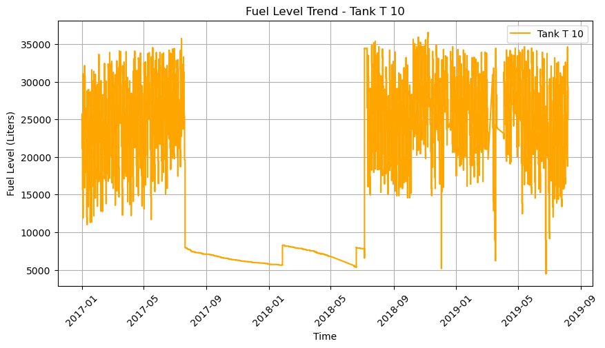

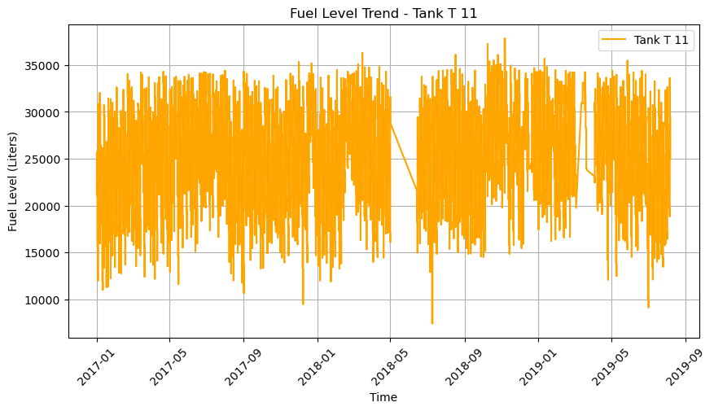

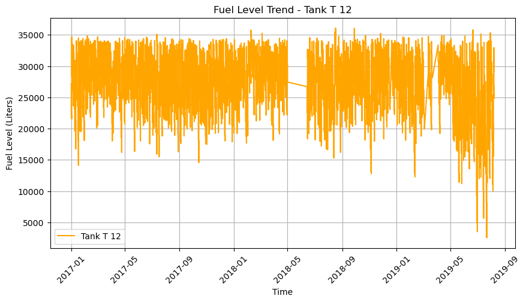

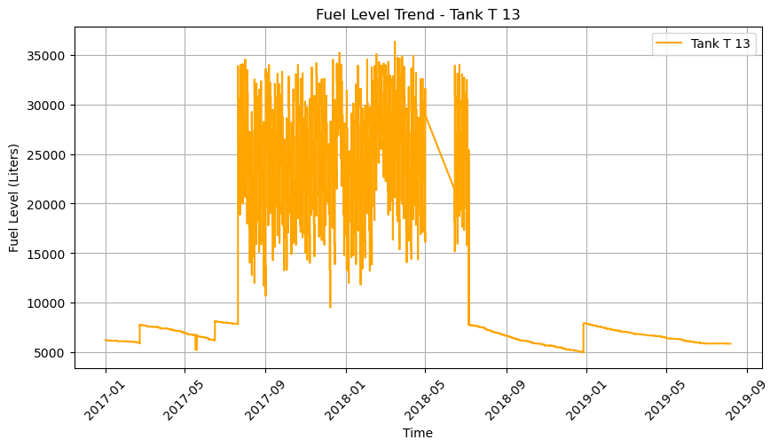

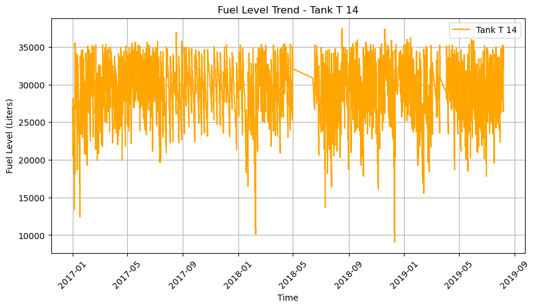

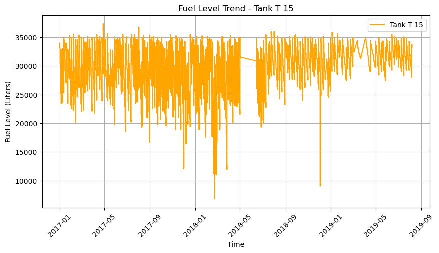

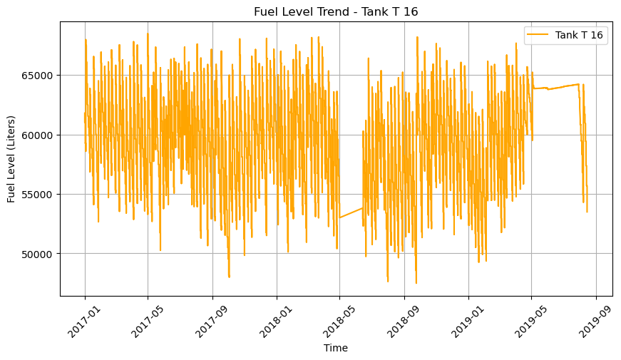

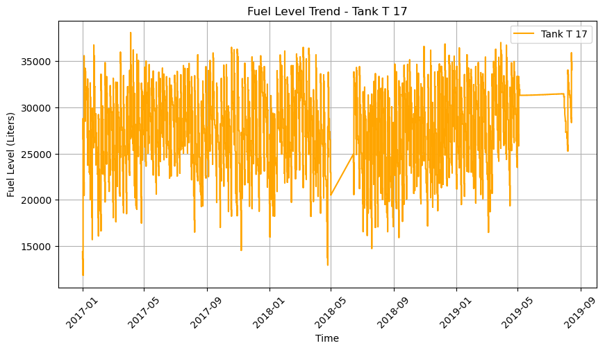

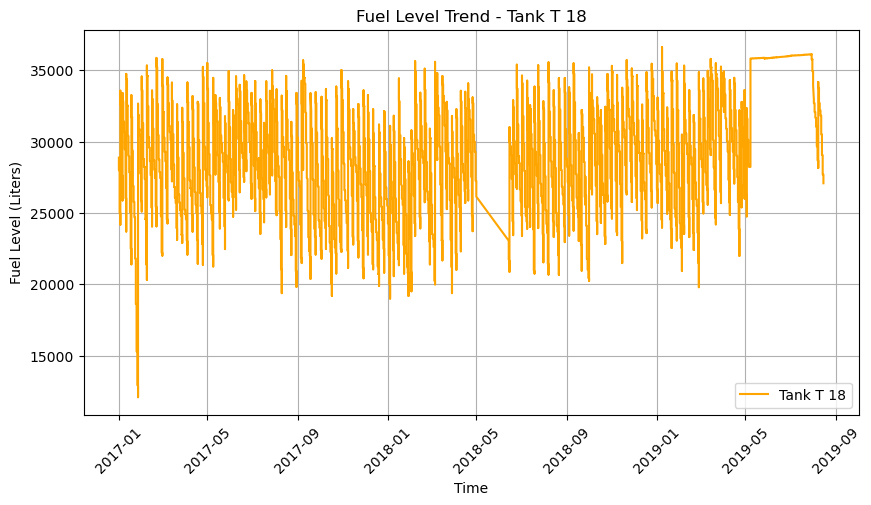

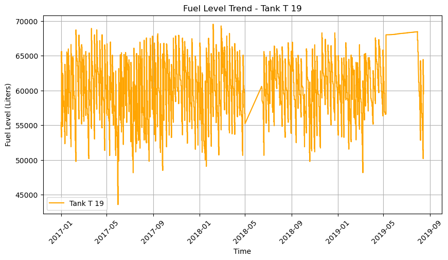

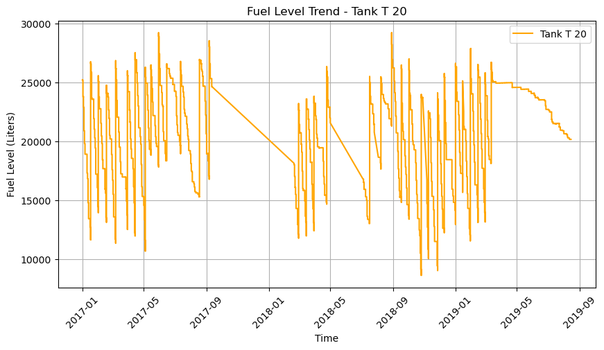

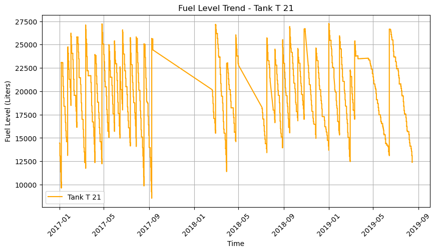

[11 more figures not shown]

```python
tanks = fuel_levels['Tank ID'].unique()

for tank in tanks:
    plt.figure(figsize=(10, 5))
    tank_data = fuel_levels[fuel_levels['Tank ID'] == tank]

    plt.plot(tank_data['Time stamp'], tank_data['Fuel Level'], color='orange', label=f'Tank {tank}')

    plt.xlabel('Time')
    plt.ylabel('Fuel Level (Liters)')
    plt.title(f'Fuel Level Trend - Tank {tank}')
    plt.xticks(rotation=45)
    plt.legend()
    plt.grid(True)
    plt.show()
```

# Stations at High Risk of Stockouts

#### Tank T 26 – Frequent stockouts, indicating poor inventory planning.

#### Tank T 29 – Significant drops to near-empty levels, increasing the risk of running out of fuel.

# Stations with Effective Inventory Management

#### Tank T 14 – Consistent fuel refills and well-maintained levels.

#### Tank T 17 – Maintains good reserves and does not run dangerously low.

#### Tank T 22 – Proper maintenance of fuel levels without erratic drops.

#### Tank T 23 – Smooth and consistent fuel trends, avoiding stockouts.

```python
invoices1 = pd.read_csv("Invoices-1.csv")
invoices1 = invoices1.dropna()
```

```python
invoices1
```

|  | Invoice Date | Invoice ID | Invoice Gas Station Location | Gross Purchase Cost | Amount Purchased | Fuel Type |
| --- | --- | --- | --- | --- | --- | --- |
| 0 | 1/2/2017 | 10000.0 | 1 | 7570.82000 | 6609.600 | G |
| 1 | 1/2/2017 | 10001.0 | 1 | 12491.85300 | 9338.736 | D |
| 3 | 1/2/2017 | 10002.0 | 2 | 17034.34500 | 13377.824 | D |
| 5 | 1/2/2017 | 10003.0 | 2 | 12616.77153 | 9432.112 | D |
| 6 | 1/2/2017 | 10004.0 | 4 | 11363.80082 | 9139.200 | D |
| ... | ... | ... | ... | ... | ... | ... |
| 2868 | 8/14/2019 | 12826.0 | 2 | 14418.62669 | 8182.960 | D |
| 2869 | 8/14/2019 | 12827.0 | 2 | 7570.82000 | 4296.640 | D |
| 2870 | 8/14/2019 | 12828.0 | 4 | 8706.44300 | 6352.416 | G |
| 2871 | 8/14/2019 | 12829.0 | 4 | 13252.72041 | 7521.264 | D |
| 2872 | 8/15/2019 | 12830.0 | 1 | 8327.90200 | 4692.864 | D |

2831 rows × 6 columns

```python
invoices1["Invoice Date"] = pd.to_datetime(invoices1["Invoice Date"])
purchase_summary = invoices1.groupby("Invoice Gas Station Location").agg(
    total_spent=("Gross Purchase Cost", "sum"),
    total_liters_purchased=("Amount Purchased", "sum"),  # Total liters
    number_of_purchases=("Invoice ID", "count")
)

purchase_summary
```

| Invoice Gas Station Location | total_spent | total_liters_purchased | number_of_purchases |
| --- | --- | --- | --- |
| 1 | 1.819895e+07 | 1.573867e+07 | 1361 |
| 2 | 7.055550e+06 | 6.283414e+06 | 632 |
| 3 | 9.403072e+05 | 8.553338e+05 | 80 |
| 4 | 3.698334e+06 | 3.211086e+06 | 356 |
| 5 | 2.482370e+06 | 2.158447e+06 | 280 |
| 6 | 4.857741e+05 | 4.413100e+05 | 42 |
| 7 | 1.173553e+05 | 1.046451e+05 | 52 |
| 8 | 3.200829e+05 | 2.837933e+05 | 28 |

```python
def calculate_discount(amount_purchased):
    if amount_purchased >= 40000:
        discount_per_liter = 0.04  # 4 cents per liter
    elif amount_purchased >= 25000:
        discount_per_liter = 0.03  # 3 cents per liter
    elif amount_purchased >= 15000:
        discount_per_liter = 0.02  # 2 cents per liter
    else:
        discount_per_liter = 0.00  # No discount

    return discount_per_liter * amount_purchased

invoices1["Discount Savings"] = invoices1["Amount Purchased"].apply(calculate_discount)
total_savings_per_station = invoices1.groupby("Invoice Gas Station Location")["Discount Savings"].sum()
total_savings_per_station
```

```
Invoice Gas Station Location
1    190587.37552
2     10296.32160
3      1955.05056
4       343.36672
5         0.00000
6      1461.89504
7         0.00000
8      1335.39648
Name: Discount Savings, dtype: float64
```

Hence, these are the cost saving of stations 1-8.

# 2. Recommend Improved Ordering Strategies

```python
tanks = pd.read_csv("Tanks-1.csv")
locations = pd.read_csv("Locations-1.csv")

tanks.dropna(inplace=True)
locations.dropna(inplace=True)

tanks_locations = tanks.merge(locations, left_on="Tank Location", right_on="Gas Station Location", how="left")
tanks_locations["Tank Type"].replace({"U": "G", "P": "G"}, inplace= True)

tanks_locations.dropna(inplace=True)

tanks_locations.drop_duplicates(inplace=True)
total_capacity_per_station = tanks_locations.groupby(["Gas Station Location", "Tank Type"])["Tank Capacity"].sum().reset_index()

def get_max_discount(order_quantity):
    if order_quantity >= 40000:
        return 0.04  # 4 cents per liter
    elif order_quantity >= 25000:
        return 0.03  # 3 cents per liter
    elif order_quantity >= 15000:
        return 0.02  # 2 cents per liter
    else:
        return 0.00  # No discount


total_capacity_per_station["Max Possible Discount"] = total_capacity_per_station["Tank Capacity"].apply(get_max_discount)

print("Maximum Possible Discount Per Station")
print(total_capacity_per_station)
```

```
Maximum Possible Discount Per Station
    Gas Station Location Tank Type  Tank Capacity  Max Possible Discount
0                      1         D          80000                   0.04
1                      1         G         160000                   0.04
2                      2         D         110000                   0.04
3                      2         G         110000                   0.04
4                      3         D          30000                   0.03
5                      3         G          30000                   0.03
6                      4         D          40000                   0.04
7                      4         G          40000                   0.04
8                      5         D          25000                   0.03
9                      5         G          25000                   0.03
10                     6         D          30000                   0.03
11                     6         G          60000                   0.04
12                     7         D           5000                   0.00
13                     7         G           5000                   0.00
14                     8         D          40000                   0.04
15                     8         G          40000                   0.04
```

### Calculate a 7-day inventory threshold based on the average daily consumption for each location and fuel type

```python
invoices1 = pd.read_csv("Invoices-1.csv")
invoices1["Invoice Date"] = pd.to_datetime(invoices1["Invoice Date"])

fuel_purchases = invoices1.groupby(["Invoice Gas Station Location", "Fuel Type"])["Amount Purchased"].sum().reset_index()

fuel_purchases["Avg Daily Consumption"] = fuel_purchases["Amount Purchased"] / 1095

fuel_purchases["7-Day Threshold"] = fuel_purchases["Avg Daily Consumption"] * 7

fuel_purchases.rename(columns={"Invoice Gas Station Location": "Gas Station Location", "Fuel Type": "Tank Type"}, inplace=True)

print("Threshold (Using 3-Year Division)")
print(fuel_purchases)
```

```
Threshold (Using 3-Year Division)
    Gas Station Location Tank Type  Amount Purchased  Avg Daily Consumption  \
0                      1         D      4.872458e+06            4449.733363
1                      1         G      1.086621e+07            9923.480563
2                      2         D      3.460900e+06            3160.639094
3                      2         G      2.822514e+06            2577.638152
4                      3         D      4.318151e+05             394.351708
5                      3         G      4.235187e+05             386.775028
6                      4         D      1.632468e+06            1490.838751
7                      4         G      1.578618e+06            1441.660069
8                      5         D      8.117340e+05             741.309545
9                      5         G      1.346713e+06            1229.874718
10                     6         D      5.462995e+04              49.890367
11                     6         G      3.866801e+05             353.132508
12                     7         D      1.108227e+04              10.120796
```

[output cut: 21 more lines]

### Compute potential savings by optimizing order quantities to maximize discounts while maintaining sufficient inventory

```python
fuel_purchases["Optimized Order Quantity"] = fuel_purchases["7-Day Threshold"]

fuel_purchases["Optimized Order Quantity"] = fuel_purchases["Optimized Order Quantity"].apply(
    lambda x: 40000 if x >= 40000 else 25000 if x >= 25000 else 15000 if x >= 15000 else x)

fuel_purchases = fuel_purchases.merge(total_capacity_per_station, on=["Gas Station Location", "Tank Type"], how="left")

fuel_purchases["Current Discount"] = fuel_purchases["7-Day Threshold"].apply(get_max_discount)
fuel_purchases["Optimized Discount"] = fuel_purchases["Optimized Order Quantity"].apply(get_max_discount)

fuel_purchases["Current Savings"] = fuel_purchases["7-Day Threshold"] * fuel_purchases["Current Discount"]
fuel_purchases["Optimized Savings"] = fuel_purchases["Optimized Order Quantity"] * fuel_purchases["Optimized Discount"]
fuel_purchases["Potential Additional Savings"] = fuel_purchases["Optimized Savings"] - fuel_purchases["Current Savings"]

print("Potential Savings by Optimizing Order Quantities")
print(fuel_purchases[["Gas Station Location", "Tank Type", "7-Day Threshold", "Optimized Order Quantity", "Current Discount",
                      "Optimized Discount","Potential Additional Savings"]])
```

```
Potential Savings by Optimizing Order Quantities
    Gas Station Location Tank Type  7-Day Threshold  Optimized Order Quantity  \
0                      1         D     31148.133538              25000.000000
1                      1         G     69464.363938              40000.000000
2                      2         D     22124.473658              15000.000000
3                      2         G     18043.467061              15000.000000
4                      3         D      2760.461954               2760.461954
5                      3         G      2707.425198               2707.425198
6                      4         D     10435.871255              10435.871255
7                      4         G     10091.620486              10091.620486
8                      5         D      5189.166816               5189.166816
9                      5         G      8609.123025               8609.123025
10                     6         D       349.232570                349.232570
11                     6         G      2471.927554               2471.927554
12                     7         D        70.845574                 70.845574
```

[output cut: 21 more lines]

# Analysis

### 1. Increase Order Quantities to Maximize Discounts

• Some gas stations currently do not qualify for supplier discounts or receive minimal savings due to low order volumes.

• Recommendation: Increase order quantities strategically to reach the next discount tier (e.g., ordering at least 15,000 liters to unlock the 2-cent discount or 25,000 liters for the 3-cent discount).

### 2. Adjust Inventory Replenishment Frequency

• Some stations place frequent small orders, missing out on bulk purchase discounts.

• Recommendation: Reduce order frequency and consolidate smaller orders into larger purchases to improve discount eligibility.

• Example 1: - Station 2 (Diesel) Current 7-day threshold: 22,124 liters Optimized order: 15,000 liters Instead of making frequent 15,000-liter orders, increase order size to at least 25,000 liters to secure a higher discount.

### 3. Identify Low-Consumption Stations for Alternative Strategies

• Some stations, especially those with low daily consumption, do not benefit from bulk orders.

• For stations with low fuel sales, ordering only when necessary or when discounts apply can be more cost-effective than maintaining high inventory.

• Example: Station 7 (Diesel) has very low daily consumption (~10 liters/day). Instead of regular purchases, buy fuel only when it reaches critical levels or combine orders with nearby stations if feasible.

# 3. Identify the Best Day for Fuel Orders

```python
df = pd.read_csv('Invoices-1.csv')
df.dropna(subset=['Invoice ID', 'Gross Purchase Cost', 'Amount Purchased', 'Fuel Type' ], inplace=True)
print(df.head())
print(df.columns)
```

```
  Invoice Date  Invoice ID  Invoice Gas Station Location  Gross Purchase Cost  \
0     1/2/2017     10000.0                             1           7570.82000
1     1/2/2017     10001.0                             1          12491.85300
3     1/2/2017     10002.0                             2          17034.34500
5     1/2/2017     10003.0                             2          12616.77153
6     1/2/2017     10004.0                             4          11363.80082

   Amount Purchased Fuel Type
0          6609.600         G
1          9338.736         D
3         13377.824         D
5          9432.112         D
6          9139.200         D
Index(['Invoice Date', 'Invoice ID', 'Invoice Gas Station Location',
       'Gross Purchase Cost', 'Amount Purchased', 'Fuel Type'],
      dtype='object')
```

```python
df['Fuel Type'] = df['Fuel Type'].str.replace('p', 'g', case=False)
print(df['Fuel Type'].unique())
```

```
['G' 'D']
```

# Examine the distribution of price-per-liter rates by day of the week

```python
df['Date'] = pd.to_datetime(df['Invoice Date'])
df['DayOfWeek'] = df['Date'].dt.dayofweek
day_names = ['Monday', 'Tuesday', 'Wednesday', 'Thursday', 'Friday', 'Saturday', 'Sunday']
df['DayName'] = df['DayOfWeek'].apply(lambda x: day_names[x])


df = df[~df['DayName'].isin(['Saturday', 'Sunday'])]
day_names_1 = ['Monday', 'Tuesday', 'Wednesday', 'Thursday', 'Friday', ]
print(df.head())
print(df.tail())

df['Price'] = df['Gross Purchase Cost'] / df['Amount Purchased']
print(df.head())
```

```
  Invoice Date  Invoice ID  Invoice Gas Station Location  Gross Purchase Cost  \
0     1/2/2017     10000.0                             1           7570.82000
1     1/2/2017     10001.0                             1          12491.85300
3     1/2/2017     10002.0                             2          17034.34500
5     1/2/2017     10003.0                             2          12616.77153
6     1/2/2017     10004.0                             4          11363.80082

   Amount Purchased Fuel Type       Date  DayOfWeek DayName
0          6609.600         G 2017-01-02          0  Monday
1          9338.736         D 2017-01-02          0  Monday
3         13377.824         D 2017-01-02          0  Monday
5          9432.112         D 2017-01-02          0  Monday
6          9139.200         D 2017-01-02          0  Monday
     Invoice Date  Invoice ID  Invoice Gas Station Location  \
2868    8/14/2019     12826.0                             2
```

[output cut: 31 more lines]

```python
gas_df = df[df['Fuel Type'] == 'G'].copy()
diesel_df = df[df['Fuel Type'] == 'D'].copy()

print("Gas Data")
print(gas_df.head())

print("Diesel Data")
print(diesel_df.head())
```

```
Gas Data
   Invoice Date  Invoice ID  Invoice Gas Station Location  \
0      1/2/2017     10000.0                             1
9      1/3/2017     10007.0                             1
10     1/3/2017     10008.0                             1
11     1/3/2017     10009.0                             2
12     1/3/2017     10010.0                             2

    Gross Purchase Cost  Amount Purchased Fuel Type       Date  DayOfWeek  \
0            7570.82000          6609.600         G 2017-01-02          0
9            7627.60115          6659.184         G 2017-01-03          1
10          32175.98500         26704.960         G 2017-01-03          1
11           9467.31041          8265.312         G 2017-01-03          1
12           9463.52500          8262.000         G 2017-01-03          1

```

[output cut: 20 more lines]

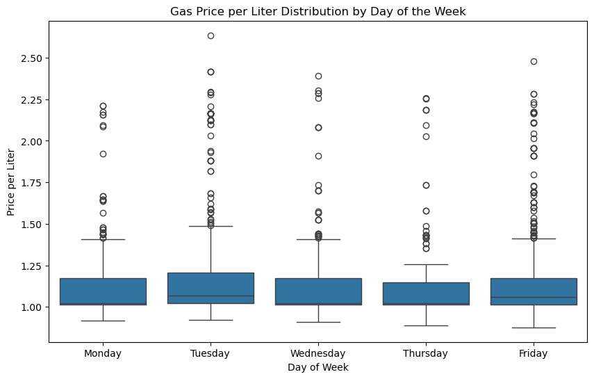

```python
import seaborn as sns
import matplotlib.pyplot as plt
plt.figure(figsize=(10, 6))
sns.boxplot(x='DayName', y='Price', data=gas_df, order=day_names_1)
plt.title('Gas Price per Liter Distribution by Day of the Week')
plt.xlabel('Day of Week')
plt.ylabel('Price per Liter')
plt.show()
```

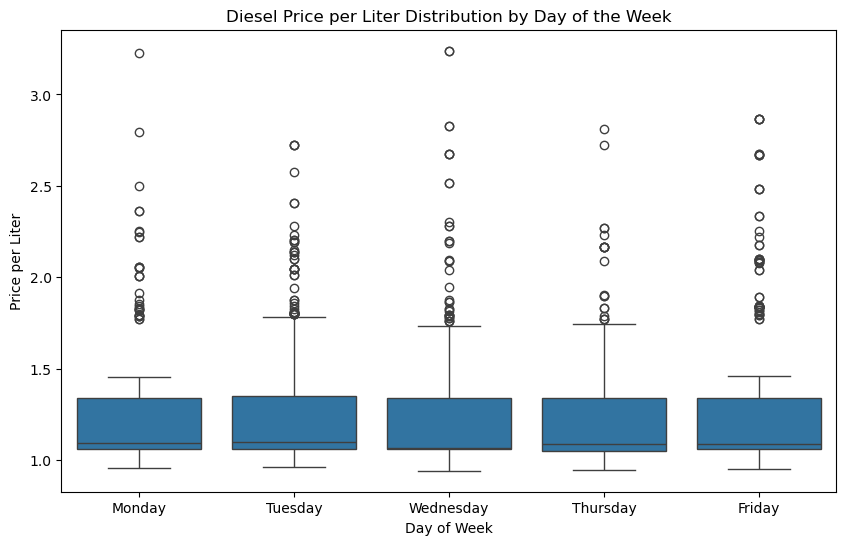

```python
plt.figure(figsize=(10, 6))
sns.boxplot(x='DayName', y='Price', data=diesel_df, order=day_names_1)
plt.title('Diesel Price per Liter Distribution by Day of the Week')
plt.xlabel('Day of Week')
plt.ylabel('Price per Liter')
plt.show()
```

# Identify the day with the lowest historical rates (by location)

## Lowest Historical Rates - Gas

```python
average_prices_gas = gas_df.groupby('DayName')['Price'].mean().sort_values()
print("Average Prices by Day (Gas):")
print(average_prices_gas)
lowest_day_gas = average_prices_gas.index[0]
print(f"The day with the lowest average price for Gas is: {lowest_day_gas}")
```

```
Average Prices by Day (Gas):
DayName
Monday       1.121444
Thursday     1.130905
Wednesday    1.132926
Friday       1.162882
Tuesday      1.209641
Name: Price, dtype: float64
The day with the lowest average price for Gas is: Monday
```

```python
savings_by_location_gas = {}

for location in gas_df['Invoice Gas Station Location'].unique():
    location_df = gas_df[gas_df['Invoice Gas Station Location'] == location].copy()
    monday_average_price = location_df[location_df['DayName'] == 'Monday']['Price'].mean()

    if pd.isna(monday_average_price):
        print(f"  No Monday purchases found for {location}. Skipping...")
        continue

    other_days_df = location_df[location_df['DayName'] != 'Monday'].copy()
    other_days_df['PotentialSavings'] = other_days_df['Price'] - monday_average_price
    other_days_df['PotentialSavings'] = other_days_df['PotentialSavings'] * other_days_df['Amount Purchased']
    potential_savings = other_days_df[other_days_df['PotentialSavings'] > 0]['PotentialSavings'].sum()

    savings_by_location_gas[location] = potential_savings

    print(f"  --- Location: {location} ---")
    print(f"    Monday Average Price: ${monday_average_price:.2f}")

    if len(other_days_df) > 0:
        print("    Purchases on days other than Monday:")
        print(other_days_df[['Date', 'DayName', 'Price', 'Amount Purchased']])
        print(f"    Potential savings if those purchases were made on Monday: ${potential_savings:.2f}")
    else:
        print("    No purchases made on days other than Monday.")


print("Potential Savings by Location Summary for Gas")
for location, savings in savings_by_location_gas.items():
    print(f"    Location: {location}, Potential Savings: ${savings:.2f}")
```

```
  --- Location: 1 ---
    Monday Average Price: $1.15
    Purchases on days other than Monday:
           Date    DayName     Price  Amount Purchased
9    2017-01-03    Tuesday  1.145426          6659.184
10   2017-01-03    Tuesday  1.204869         26704.960
18   2017-01-05   Thursday  1.145428          8262.000
24   2017-01-06     Friday  1.169780         14568.480
25   2017-01-06     Friday  1.204869         26406.496
...         ...        ...       ...               ...
2840 2019-08-02     Friday  1.502719         21406.800
2841 2019-08-02     Friday  1.428413          5830.176
2853 2019-08-07  Wednesday  1.442700          5906.256
2858 2019-08-09     Friday  1.416780          6679.600
2867 2019-08-14  Wednesday  1.370574          5891.168
```

[output cut: 202 more lines]

## Lowest Historical Rates - Diesel

```python
average_prices_diesel = diesel_df.groupby('DayName')['Price'].mean().sort_values()
print("Average Prices by Day (Diesel):")
print(average_prices_diesel)
lowest_day_diesel = average_prices_diesel.index[0]
print(f"\nThe day with the lowest average price for Diesel is: {lowest_day_diesel}")
```

```
Average Prices by Day (Diesel):
DayName
Thursday     1.249957
Monday       1.251885
Wednesday    1.253820
Friday       1.285570
Tuesday      1.327193
Name: Price, dtype: float64

The day with the lowest average price for Diesel is: Thursday
```

```python
savings_by_location_diesel = {}

for location in diesel_df['Invoice Gas Station Location'].unique():
    location_df = diesel_df[diesel_df['Invoice Gas Station Location'] == location].copy()
    monday_average_price = location_df[location_df['DayName'] == 'Monday']['Price'].mean()

    if pd.isna(monday_average_price):
        print(f"  No Monday purchases found for {location}. Skipping...")
        continue

    other_days_df = location_df[location_df['DayName'] != 'Monday'].copy()
    other_days_df['PotentialSavings'] = other_days_df['Price'] - monday_average_price
    other_days_df['PotentialSavings'] = other_days_df['PotentialSavings'] * other_days_df['Amount Purchased']
    potential_savings = other_days_df[other_days_df['PotentialSavings'] > 0]['PotentialSavings'].sum()

    savings_by_location_diesel[location] = potential_savings

    print(f"  --- Location: {location} ---")
    print(f"    Monday Average Price: ${monday_average_price:.2f}")

    if len(other_days_df) > 0:
        print("    Purchases on days other than Monday:")
        print(other_days_df[['Date', 'DayName', 'Price', 'Amount Purchased']])
        print(f"Potential savings if those purchases were made on Monday: ${potential_savings:.2f}")
    else:
        print("    No purchases made on days other than Monday.")

print("Potential Savings by Location Summary for Diesel")
for location, savings in savings_by_location_diesel.items():
    print(f"    Location: {location}, Potential Savings: ${savings:.2f}")
```

```
  --- Location: 1 ---
    Monday Average Price: $1.28
    Purchases on days other than Monday:
           Date    DayName     Price  Amount Purchased
8    2017-01-03    Tuesday  1.337640          4239.216
15   2017-01-04  Wednesday  1.337639          5659.840
20   2017-01-05   Thursday  1.337639          7074.800
23   2017-01-06     Friday  1.337639          7074.800
36   2017-01-11  Wednesday  1.337638          8492.592
...         ...        ...       ...               ...
2850 2019-08-06    Tuesday  1.802851          3149.520
2851 2019-08-06    Tuesday  1.802848          7487.472
2852 2019-08-07  Wednesday  1.796008          4847.664
2859 2019-08-09     Friday  1.831037          8273.568
2872 2019-08-15   Thursday  1.774588          4692.864

[439 rows x 4 columns]
Potential savings if those purchases were made on Monday: $298119.36
  --- Location: 2 ---
    Monday Average Price: $1.19
    Purchases on days other than Monday:
           Date    DayName     Price  Amount Purchased
16   2017-01-04  Wednesday  1.337639         11319.680
21   2017-01-05   Thursday  1.337638          8515.232
27   2017-01-06     Friday  1.337638          4247.712
38   2017-01-11  Wednesday  1.337639          8489.760
39   2017-01-11  Wednesday  1.337639          7074.800
...         ...        ...       ...               ...
2622 2019-05-08  Wednesday  2.675731          4244.160
2854 2019-08-07  Wednesday  1.796008          6323.040
2855 2019-08-07  Wednesday  1.796008          4847.664
2868 2019-08-14  Wednesday  1.762031          8182.960
2869 2019-08-14  Wednesday  1.762033          4296.640

[302 rows x 4 columns]
Potential savings if those purchases were made on Monday: $194942.09
  --- Location: 4 ---
    Monday Average Price: $1.29
    Purchases on days other than Monday:
           Date    DayName     Price  Amount Purchased
```

[output cut: 101 more lines]

```
991  2017-11-03   Friday  1.039163          1621.024
1408 2018-03-23   Friday  1.060220          2499.280
2132 2018-11-16   Friday  1.136073           982.944
2456 2019-03-08   Friday  1.837298           840.608
2603 2019-04-30  Tuesday  2.723214           319.712
Potential savings if those purchases were made on Monday: $1480.42
Potential Savings by Location Summary for Diesel
    Location: 1, Potential Savings: $298119.36
    Location: 2, Potential Savings: $194942.09
    Location: 4, Potential Savings: $111334.74
    Location: 5, Potential Savings: $84040.58
    Location: 3, Potential Savings: $30440.75
    Location: 6, Potential Savings: $8727.21
    Location: 8, Potential Savings: $8239.39
    Location: 7, Potential Savings: $1480.42
```